# Superstore Sales Predictor

Sarah Haley, slh54@drexel.edu

Zach Carlson, zc378@drexel.edu

Nancy Melucci, njm99@drexel.edu

November 14, 2021

#### Libraries

```r
library(tidyverse) #Tidyverse v3.6.3
library(lubridate)
library(ggplot2)
library(ggfortify)
library(knitr)
library(kableExtra)
library(zoo)
library(forecast)
```

### ARIMA in R and Time Series Forecasting

FOr this project we will be using the ARIMA forecasting model which in turn is based on the Box-Jenkins Methodology,with the Autoregressive Integrated Moving Average model(ARIMA). This is comprised of three major steps:

1. Conditioning the data and selecting a model (from chapter 8 in Data Science and Big Data Analytics) -identify and account for any trends or seasonality in the time series -examine the remaining time series for any trends or seasonality in the time series
2. Estimate the model parameters
3. Assess the model and return to step one if necessary

*Time series data* is made up of four possible components: Trend [T], Cycle [C], Seasonality [S], and Random[R]. In our data, there appears to be strong seasonality trends, although the magnitude is hard to tell. It may also have cyclicity but that is also hard to tell with the current graphs. To that end we will employ a few libraries that were developed to deal with these particuar issues in Time Series data.

So to begin, we will start looking at the data and getting a sense of its shape and possibilities.

## Import and View the Data

```r
sales_raw <- read.csv("./data/superstore_dataset2011-2015.csv", header = TRUE, sep = ",")

sales_raw <- mutate_at(sales_raw, vars("Order.Date","Ship.Date"),funs(dmy))
```

The dates need to be converted using the `lubridate` library. The two date columns are now correctly reading as `<date>`.

```r
sales_raw %>%
  select(Order.Date, Ship.Date) %>%
  head(., 6)
```

```
##   Order.Date  Ship.Date
## 1 2011-01-01 2011-01-06
## 2 2011-01-01 2011-01-08
## 3 2011-01-01 2011-01-05
## 4 2011-01-01 2011-01-05
## 5 2011-01-01 2011-01-08
## 6 2011-01-01 2011-01-08
```

#### Initial Observations

Using the dpylr package’s glimpse function, we see there are

- `51,290` instances with `24` features
- lubridate dates are now in `YYYY-MM-DD` format
- most features are factored but there are also int and nums where sensible:
  - Quantity is in integers
  - Sales is num (floating point)
  - For ease of analysis, we will assume all sales are in USD
  - Sales column row-wise represents the total amount by Quantity(1-n)

For the superstore data we want to know a number of things that time series can help us understand. Things such as:

- Are Sales & Profits increasing over time?
- What categories of sales are most profitable over time?
- What region has the most sales and are the most profitable over time?
- Predicted growth rates and declines will help us establish which markets, regions, and products we should be investing in for best profitability.

#### Exploratory Data Analysis

```r
dplyr::glimpse(sales_raw, width = getOption("width"))
```

```
## Observations: 51,290
## Variables: 24
## $ Row.ID         <int> 42433, 22253, 48883, 11731, 22255, 22254, 21613, 346...
## $ Order.ID       <fct> AG-2011-2040, IN-2011-47883, HU-2011-1220, IT-2011-3...
## $ Order.Date     <date> 2011-01-01, 2011-01-01, 2011-01-01, 2011-01-01, 201...
## $ Ship.Date      <date> 2011-01-06, 2011-01-08, 2011-01-05, 2011-01-05, 201...
## $ Ship.Mode      <fct> Standard Class, Standard Class, Second Class, Second...
## $ Customer.ID    <fct> TB-11280, JH-15985, AT-735, EM-14140, JH-15985, JH-1...
## $ Customer.Name  <fct> Toby Braunhardt, Joseph Holt, Annie Thurman, Eugene ...
## $ Segment        <fct> Consumer, Consumer, Consumer, Home Office, Consumer,...
## $ City           <fct> Constantine, Wagga Wagga, Budapest, Stockholm, Wagga...
## $ State          <fct> Constantine, New South Wales, Budapest, Stockholm, N...
## $ Country        <fct> Algeria, Australia, Hungary, Sweden, Australia, Aust...
## $ Postal.Code    <int> NA, NA, NA, NA, NA, NA, NA, 92691, NA, NA, NA, NA, N...
## $ Market         <fct> Africa, APAC, EMEA, EU, APAC, APAC, APAC, US, Africa...
## $ Region         <fct> Africa, Oceania, EMEA, North, Oceania, Oceania, Cent...
## $ Product.ID     <fct> OFF-TEN-10000025, OFF-SU-10000618, OFF-TEN-10001585,...
## $ Category       <fct> Office Supplies, Office Supplies, Office Supplies, O...
## $ Sub.Category   <fct> Storage, Supplies, Storage, Paper, Furnishings, Pape...
## $ Product.Name   <fct> "Tenex Lockers, Blue", "Acme Trimmer, High Speed", "...
## $ Sales          <dbl> 408.300, 120.366, 66.120, 44.865, 113.670, 55.242, 2...
## $ Quantity       <int> 2, 3, 4, 3, 5, 2, 2, 2, 1, 3, 5, 2, 6, 5, 3, 2, 3, 5...
## $ Discount       <dbl> 0.00, 0.10, 0.00, 0.50, 0.10, 0.10, 0.00, 0.15, 0.00...
## $ Profit         <dbl> 106.1400, 36.0360, 29.6400, -26.0550, 37.7700, 15.34...
## $ Shipping.Cost  <dbl> 35.46, 9.72, 8.17, 4.82, 4.70, 1.80, 57.30, 54.64, 5...
## $ Order.Priority <fct> Medium, Medium, High, High, Medium, Medium, Critical...
```

Right away we can see there are a lot of NA values for Postal.Code so we will drop that column; we will not be using it for this project.

```r
sales <- subset(sales_raw, select = -c(Postal.Code))
```

Additionally, we will also add a few columns to the data set to make it easier for analysis throughout the project. A year column, a YearMonth column, a monthabbr column, and a month date object. Note some of these are not considered actual date parts but can be wrangled to look like dates.

```r
sales <- sales %>%
  mutate(
    YearMonth = format(Order.Date, "%Y-%m")
  ) #character
sales <- sales %>%
  mutate(
    year = year(Order.Date), monthAbbr = month(Order.Date, label = TRUE)
  ) #Ordinal

sales$month <- as.Date(cut(sales$Order.Date, breaks = "month")) #Date
```

A quick look at the new columns:

```r
sales %>%
  select(YearMonth, year, month, monthAbbr) %>%
  tail(., n = 10)
```

```
##       YearMonth year      month monthAbbr
## 51281   2014-12 2014 2014-12-01       Dec
## 51282   2014-12 2014 2014-12-01       Dec
## 51283   2014-12 2014 2014-12-01       Dec
## 51284   2014-12 2014 2014-12-01       Dec
## 51285   2014-12 2014 2014-12-01       Dec
## 51286   2014-12 2014 2014-12-01       Dec
## 51287   2014-12 2014 2014-12-01       Dec
## 51288   2014-12 2014 2014-12-01       Dec
## 51289   2014-12 2014 2014-12-01       Dec
## 51290   2014-12 2014 2014-12-01       Dec
```

And here we will look at a few 30,000ft summary statistics around the factors affecting Revenue (Sales, Quantity, Discount Rates, Shipping Costs, and Profits) over the four year lifecycle:

```r
kable(sales %>%
        select(Sales, Quantity, Discount, Shipping.Cost, Profit) %>%
        summary()
  , format = "html", digits = 2) %>%
  kable_styling(bootstrap_options= c("striped"), full_width = F, font_size = 14)
```

|  | Sales | Quantity | Discount | Shipping.Cost | Profit |
| --- | --- | --- | --- | --- | --- |
|  | Min. : 0.444 | Min. : 1.000 | Min. :0.0000 | Min. : 0.00 | Min. :-6599.98 |
|  | 1st Qu.: 30.759 | 1st Qu.: 2.000 | 1st Qu.:0.0000 | 1st Qu.: 2.61 | 1st Qu.: 0.00 |
|  | Median : 85.053 | Median : 3.000 | Median :0.0000 | Median : 7.79 | Median : 9.24 |
|  | Mean : 246.491 | Mean : 3.477 | Mean :0.1429 | Mean : 26.38 | Mean : 28.61 |
|  | 3rd Qu.: 251.053 | 3rd Qu.: 5.000 | 3rd Qu.:0.2000 | 3rd Qu.: 24.45 | 3rd Qu.: 36.81 |
|  | Max. :22638.480 | Max. :14.000 | Max. :0.8500 | Max. :933.57 | Max. : 8399.98 |

`Discount` is in a percentage format already, showing an average at about 14% and the average quantity per sale is relatively low with an IQR of 2-5 and a median value of 3 per sale item. We will look more closely at sales volume trends shortly.

Dropping `Quantity` and `Discount` data, we can see the main revenue factors in side-by-side box plots. Total revenue, or the Sales plot, is the highest, as it should be, and Profit and Shipping Cost are subsets of that number. Profit is also quite large in the plot but Shipping Costs are not far behind, leading to some questions around efficiency for upper management to contemplate further. Additionally, there are a large number of outliers in the data and it is highly positively skewed, hence the addition of log10 on the y scale.

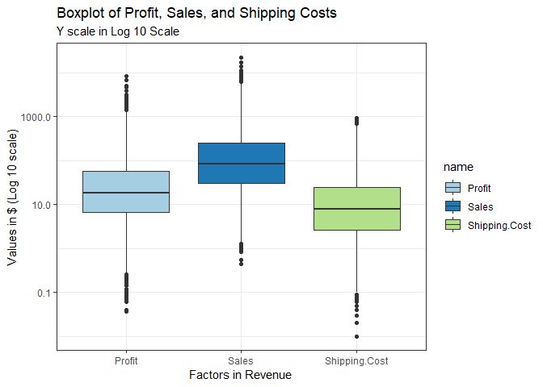

```r
options(scipen=999)# prevents scientific numbering on axis
sales %>%
  select(Sales, Shipping.Cost, Profit) %>%
  pivot_longer(cols = everything()) %>%
  ggplot(aes(x= name, y = value, fill=name)) +
    geom_boxplot()+
    xlab("Factors in Revenue") +
    scale_y_log10("Values in $ (Log 10 scale)")  +
  ggtitle("Boxplot of Profit, Sales, and Shipping Costs", subtitle = "Y scale in Log 10 Scale")+
    scale_fill_brewer(palette = "Paired")+
    theme_bw()
```

Looking a little more closely at Sales by year:

```r
kable(sales %>%
  group_by(year) %>%
  summarise(total_sales = sum(Sales),  mean_sales = mean(Sales), median_sales = median(Sales), max_sales = max(Sales), min_sales = min(Sales)), format = "html", digits = 2) %>%
  kable_styling(full_width = F, font_size = 12)
```

| year | total_sales | mean_sales | median_sales | max_sales | min_sales |
| --- | --- | --- | --- | --- | --- |
| 2011 | 2259451 | 251.11 | 84.27 | 22638.48 | 0.85 |
| 2012 | 2677439 | 244.25 | 87.14 | 6354.95 | 0.98 |
| 2013 | 3405746 | 246.81 | 85.23 | 17499.95 | 0.84 |
| 2014 | 4299866 | 245.27 | 84.48 | 13999.96 | 0.44 |

Total sales have grown every year while average sales have not. It looks like a lot of small sales make up the vast majority of the revenue for this company. Quantity sold, (our sales volume), should help us understand if this supposition is true and help us determine if there are visible seasonal trends. Let’s start by looking at monthly sales trends, aggregating the `Quantity` column by month.

```r
monthly_sales_quantity <- sales %>%
  group_by(year, monthAbbr) %>%
  summarise(total.qty = sum(Quantity))

tail(monthly_sales_quantity, 24)
```

```
## # A tibble: 24 x 3
## # Groups:   year [2]
##     year monthAbbr total.qty
##    <dbl> <ord>         <int>
##  1  2013 Jan            2413
##  2  2013 Feb            2102
##  3  2013 Mar            2686
##  4  2013 Apr            2688
##  5  2013 May            3808
##  6  2013 Jun            5327
##  7  2013 Jul            3252
##  8  2013 Aug            4934
##  9  2013 Sep            5793
## 10  2013 Oct            3883
## # ... with 14 more rows
```

And used to visualize, we get:

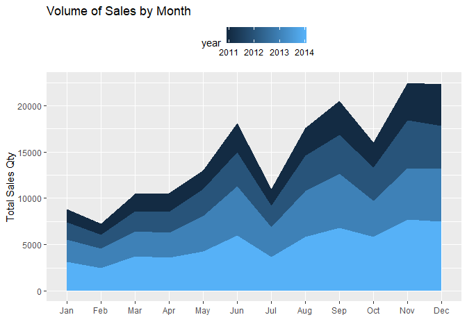

```r
monthly_sales_quantity %>%
  ggplot(aes(x = monthAbbr, y = total.qty, group = year)) +
  geom_area(aes(fill=year), position = "stack") +
  labs(title = "Volume of Sales by Month", x= "", y ="Total Sales Qty") +
  scale_y_continuous() +
  theme(legend.position = "top")
```

There are obvious seasonal trends in terms of quantity sold with slow and steady growth throughout the year capped with three peaks, and a bulk of sales happening in the last quarter of the year. There is a small peak between April through to July, another between July and October, and the third (and largest) trending from October to the end of December.

We will continue to look at total quantity (volume of sales) and total sales (revenue) over the course of this project. Since the per sale dollar amount already reflects the unit by price * quantity, the charts below are representing the `volume` of sales per month by individual days’ (points) `revenue`. Each point represents a Sales line item multiplied the quantity sold.

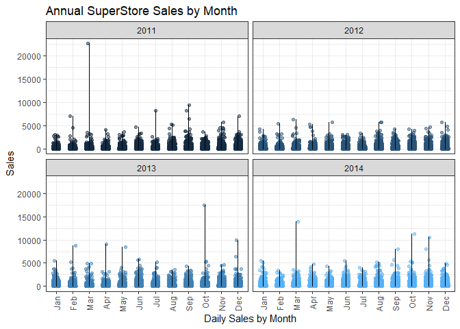

```r
ggplot(sales, aes(monthAbbr, Sales)) +
  #geom_point(color= "steelblue")
geom_jitter(alpha =0.5, aes(color=year), position = position_jitter(width = .2))+
  labs(x = "Daily Sales by Month",
       y = " Sales",
       title = "Annual SuperStore Sales by Month") +
  geom_line()+
  #stat_summary(fun.y = sum, geom = "bar")+
  #geom_bar(stat = "identity") +
  facet_wrap(~year(month),ncol = 2) +
  theme_bw() +
  theme(legend.position = "none",axis.text.x = element_text(angle = 90,
                                   vjust = 0.5,
                                   hjust = 1))
```

Looking at this panel, we see we have a number of outliers in the data and that most of the sales amounts per sale are below $5000 (and often much less than that). Also, it is apparent that there was less variance in the 2012 month to month data points than from the other years. Finally, outside of the obvious connection between sales and quantity sold, a closer look at the relationship between sales and profits can reveal more details.

Let’s look at a few of the ouliers to see if we can determine what is causing them.

```r
kable(sales %>%
  group_by(year) %>% arrange(year) %>%
  select(., c(Order.Date, Customer.Name, Segment, Product.Name, Sales,   Quantity, Discount, Profit)) %>%
    filter(Sales == max(Sales)),format = "html", digits = 2, table.attr = "style='width:40%;'") %>%
  kable_styling(full_width = F, font_size = 12)
```

| year | Order.Date | Customer.Name | Segment | Product.Name | Sales | Quantity | Discount | Profit |
| --- | --- | --- | --- | --- | --- | --- | --- | --- |
| 2011 | 2011-03-18 | Sean Miller | Home Office | Cisco TelePresence System EX90 Videoconferencing Unit | 22638.48 | 6 | 0.5 | -1811.08 |
| 2012 | 2012-03-16 | Christopher Martinez | Consumer | Fellowes PB500 Electric Punch Plastic Comb Binding Machine with Manual Bind | 6354.95 | 5 | 0.0 | 3177.47 |
| 2013 | 2013-10-03 | Tamara Chand | Corporate | Canon imageCLASS 2200 Advanced Copier | 17499.95 | 5 | 0.0 | 8399.98 |
| 2014 | 2014-03-24 | Raymond Buch | Consumer | Canon imageCLASS 2200 Advanced Copier | 13999.96 | 4 | 0.0 | 6719.98 |

The above appear to be genuine sales, although they are certainly much larger than the average sales and very rare in the overall dataset. Also, they appear to be strangely segmented - I have yet to meet someone who buys 6 video conferencing units for their `Home Office` and the Canon sales are each attributed to a different segment for the same product.

#### Sales and Profit Relationships

Now to plot the multiple line plots to look at the relationship between the “Sales” and “Profit” columns by year by month.

```r
monthly_sales_profit <- sales %>%
  group_by(month) %>%
  summarise_at(c("Sales", "Profit"), sum)


MSP <-monthly_sales_profit %>%
  gather(key = "variable", value = "values", -month)

MSP
```

```
## # A tibble: 96 x 3
##    month      variable  values
##    <date>     <chr>      <dbl>
##  1 2011-01-01 Sales     98898.
##  2 2011-02-01 Sales     91152.
##  3 2011-03-01 Sales    145729.
##  4 2011-04-01 Sales    116916.
##  5 2011-05-01 Sales    146748.
##  6 2011-06-01 Sales    215207.
##  7 2011-07-01 Sales    115510.
##  8 2011-08-01 Sales    207581.
##  9 2011-09-01 Sales    290214.
## 10 2011-10-01 Sales    199071.
## # ... with 86 more rows
```

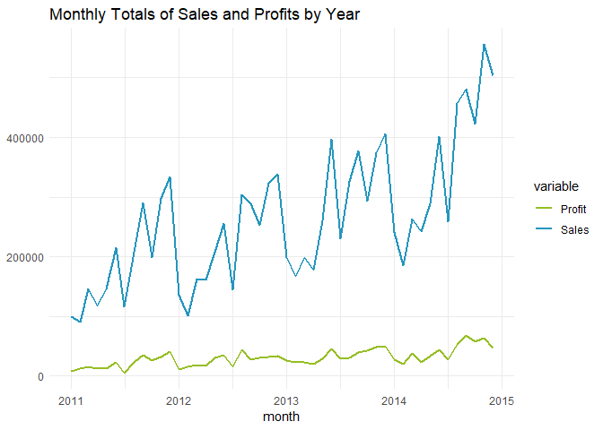

```r
options(scipen=999)# prevents scientific numbering on axis
ggplot(MSP, aes(x = month, y = values)) +
  geom_line(aes(color = variable), size = 1)+
  labs(title = "Monthly Totals of Sales and Profits by Year", y=NULL)+
  scale_color_manual(values = c("#96be25", "#2596be"))+
  theme_minimal()
```

It is really hard to see if anything is changing at all with profits. So we will plot again using a log 10 scale on the Y-axis.

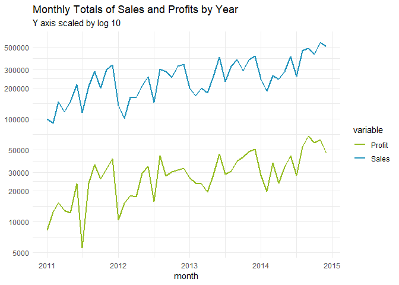

```r
options(scipen=999)# prevents scientific numbering on axis
ggplot(MSP, aes(x = month, y = values)) +
  geom_line(aes(color = variable), size = 1)+
  labs(title = "Monthly Totals of Sales and Profits by Year", subtitle = "Y axis scaled by log 10", y=NULL)+
  scale_color_manual(values = c("#96be25", "#2596be"))+
  theme_minimal()+
  scale_y_log10(breaks = scales::log_breaks(10))
```

Let’s see how correlated the two values are:

```r
cor(sales$Sales, sales$Profit)
```

```
## [1] 0.4849181
```

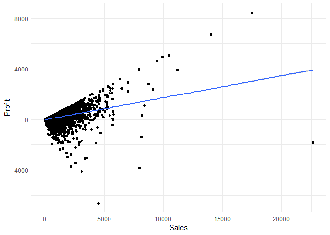

```r
ggplot(sales, aes(Sales, Profit)) +
  geom_point()+
  geom_smooth(method = "lm") +
  theme_minimal()
```

and looking at a scatter plot is not very helpful. The raw values of the data show a poor alignment between the two values.

Let’s standardize for easier readability. To do that we will first look at the percentage change month over month for Sales and Profits.

```r
MSP<-MSP %>%
  mutate(pct_change = (values/lag(values)-1)*100)

tail(MSP, 5)
```

```
## # A tibble: 5 x 4
##   month      variable values pct_change
##   <date>     <chr>     <dbl>      <dbl>
## 1 2014-08-01 Profit   53543.      91.0
## 2 2014-09-01 Profit   67979.      27.0
## 3 2014-10-01 Profit   58210.     -14.4
## 4 2014-11-01 Profit   62857.       7.98
## 5 2014-12-01 Profit   46917.     -25.4
```

Charting the data we get:

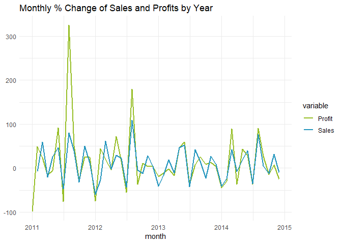

```r
options(scipen=999)# prevents scientific numbering on axis
ggplot(MSP, aes(x = month, y = pct_change)) +
  geom_line(aes(color = variable), size = 1)+
  labs(title = "Monthly % Change of Sales and Profits by Year", y=NULL)+
  scale_color_manual(values = c("#96be25", "#2596be"))+
  theme_minimal()
```

This makes things a little clearer and shows that sales and profits are both trending at similar rates, with profits being much less stable and more variable than sales.

### Rolling Averages

Further standardizing, we will next look a the rolling means:

```r
daily_sales <- sales %>%
  select(Order.Date, Sales, Quantity, Profit, Shipping.Cost) %>%
  group_by(Order.Date) %>%
  summarise(
          daSales = sum(Sales),
         daProfits = sum(Profit),
         daShipping = sum(Shipping.Cost))
rolling <-daily_sales %>%
    mutate(sales_01da = rollmean(daSales, k = 1, fill = NA),
         sales_07da = rollmean(daSales, k = 7, fill = NA),
         sales_30da = rollmean(daSales, k = 30, fill = NA),
         sales_360da = rollmean(daSales, k = 360, fill = NA),
         profits_01da = rollmean(daProfits, k = 1, fill = NA),
         profits_07da = rollmean(daProfits, k = 7, fill = NA),
         profits_30da = rollmean(daProfits, k = 30, fill = NA),
         profits_360da = rollmean(daProfits, k = 360, fill = NA))


rolling <- subset(rolling, select = -c(daSales, daProfits, daShipping))
rolling
```

```
## # A tibble: 1,430 x 9
##    Order.Date sales_01da sales_07da sales_30da sales_360da profits_01da
##    <date>          <dbl>      <dbl>      <dbl>       <dbl>        <dbl>
##  1 2011-01-01       809.        NA          NA          NA       199.
##  2 2011-01-02       314.        NA          NA          NA         3.12
##  3 2011-01-03      4504.        NA          NA          NA       185.
##  4 2011-01-04      2809.      2835.         NA          NA       635.
##  5 2011-01-05      3662.      3618.         NA          NA      1053.
##  6 2011-01-06       623.      3690.         NA          NA        86.1
##  7 2011-01-07      7123.      4017.         NA          NA      1541.
##  8 2011-01-08      6293.      4537.         NA          NA      -631.
##  9 2011-01-09       814.      4390.         NA          NA      -118.
## 10 2011-01-10      6794.      4670.         NA          NA      1444.
## # ... with 1,420 more rows, and 3 more variables: profits_07da <dbl>,
## #   profits_30da <dbl>, profits_360da <dbl>
```

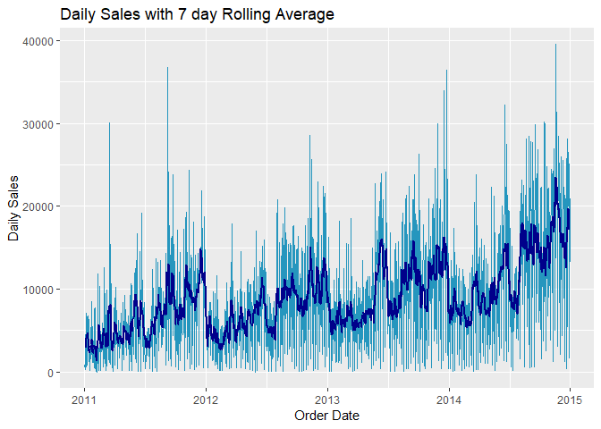

```r
rs <- ggplot(rolling, aes(x = Order.Date, y = sales_01da)) +
  geom_line(color="#2596be") +
  geom_line(aes(y = sales_07da), color = "dark blue", size = 0.75)+
  labs (x = "Order Date", y = "Daily Sales", title = "Daily Sales with 7 day Rolling Average")

rs
```

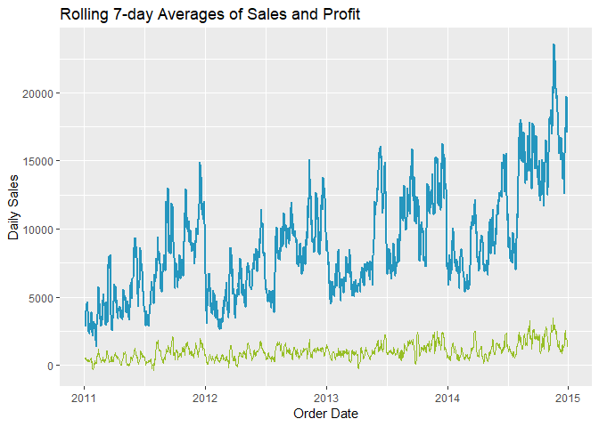

```r
sp7 <- ggplot(rolling, aes(x = Order.Date)) +
  geom_line(aes(y = profits_07da), color="#96be25") +
  geom_line(aes(y = sales_07da), color = "#2596be", size = 0.75)+
  labs (x = "Order Date", y = "Daily Sales", title = "Rolling 7-day Averages of Sales and Profit")

sp7
```

[figure not shown]

```r
ggplot(rolling, aes(x = Order.Date))
```

### ARIMA in R and Time Series Forecasting

Now we come to the heart of the matter, using the Box-Jenkins Methodology,with the Autoregressive Integrated Moving Average model(ARIMA). This is comprised of three major steps:

1. Conditioning the data and selecting a model (from chapter 8 in Data Science and Big Data Analytics) -identify and account for any trends or seasonality in the time series -examine the remaining time series for any trends or seasonality in the time series
2. Estimate the model parameters
3. Assess the model and return to step one if necessary

*Time series data* is made up of four possible components: Trend [T], Cycle [C], Seasonality [S], and Random[R]. In our data, there appears to be strong seasonality trends, although the magnitude is hard to tell. It may also have cyclicity but that is also hard to tell with the current graphs. To that end we will employ a few libraries that were developed to deal with these particuar issues in Time Series data.

In R this is done by converting the information to a timeseries object and then use the forecast or other similar libraries to perform some decomposition on the data. Decomposition is a process of seperating out different time series peices, rendering the data in a more “predictable” format.

For the ARIMA model we must also ensure the data is in a `stationary` format. - the mean of Y(t) is a constant for all values of t - the variance of Y(t) is finite - the covariance of Y(t) and Y(t + h) depends only on the value of h = 0,1,2,…for all of t.

#### Using the Time Series Object in R

Converting the monthly sales information into a ts (time series) object in R, we can use its native library and the stats package to decompose the monthly sales data to see if we are on the right track. This will also confirm which parts of the data are due to randomness, which is something we cannot gleen from the earlier charts.

I am going to plot the STL (seasonal and trend decomposition using Loess) for `Sales` and then we will look at some of the other factors seperately.

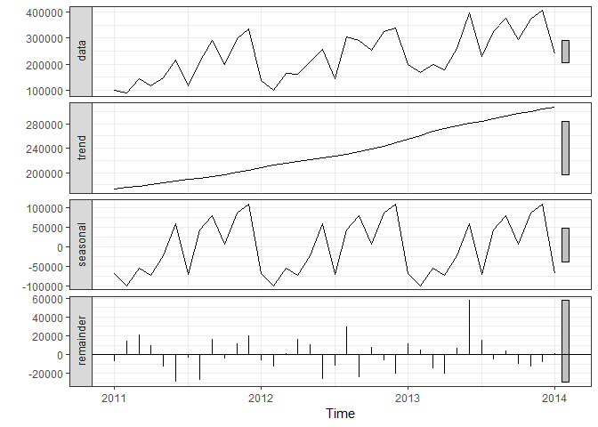

```r
monthly_revenue_factors <- sales %>%
  group_by(month) %>%
  summarise(total.sales = sum(Sales), total.profit = sum(Profit), total.shipping = sum(Shipping.Cost))

monthly_ts <-ts(monthly_revenue_factors[,2:4], start = 2011, end = 2014, freq = 12)


monthly_sales <- sales %>%
   group_by(month) %>%
   summarise(total.sales = sum(Sales))

sales_ts <- ts(monthly_sales[,2], start = 2011, end = 2014, frequency = 12)

sales_ts %>%
  stl( s.window = "period") %>%
  autoplot() +
  theme_bw()
```

With everything split out, it is possible to see the trend and seasonal data very clearly. Sales are growing and seasonality cannot be denied. The `Random` or reaminder data is also often used for prediction as it can contain underpinning structure within the ‘noise’ letting us know whether or not we have achieved our goals with the data.

Since we know there is seasonality in the data, it means the series is not stationary and for the ARIMA models of prediction, we will need to do a litle work.

Another chart that is a part of the Box Jenkins Methodology is the ACF or Autocorrelation Function. This function provides an autocorrelation with previous lags or time periods of a dataset with itself. The ACF will peak around seasonal lags or at the average cycle length.

Below is an ACF plot on just the monthly sales data. The dashed lines are there to show when a correlation is significantly above or below zero. The lags at 1 and 3 and 12 show that the data is likley not happening by random chance. This is data we can use to build a forcasting model.

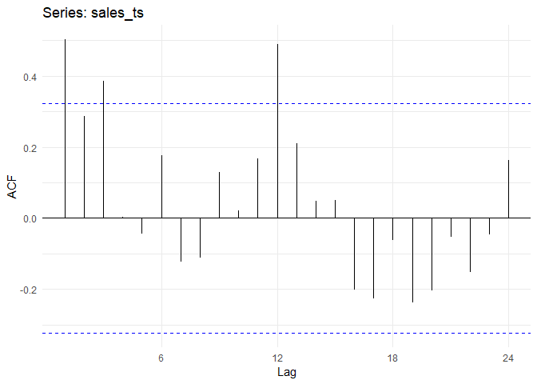

```r
ggAcf(sales_ts) +
  theme_minimal()
```

Here, we will start with some basic predictions of the data.

```r
library(caret)
# training and test data
set.seed(42)

index = createDataPartition(sales$Sales, p = 0.70, list = FALSE)
train = sales[index, ]
test = sales[-index, ]
```

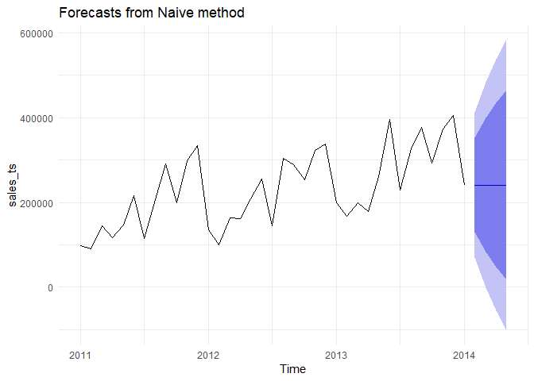

```r
nf_sales <- naive(sales_ts, h = 4)

autoplot(nf_sales) +
  theme_minimal()
```

```r
summary(nf_sales)
```

```
##
## Forecast method: Naive method
##
## Model Information:
## Call: naive(y = sales_ts, h = 4)
##
## Residual sd: 87418.4309
##
## Error measures:
##                    ME     RMSE      MAE       MPE     MAPE     MASE       ACF1
## Training set 3954.724 87418.43 72274.79 -5.393697 34.19143 1.518341 -0.3165428
##
## Forecasts:
##          Point Forecast     Lo 80    Hi 80      Lo 95    Hi 95
## Feb 2014       241268.6 129237.33 353299.8   69931.58 412605.5
## Mar 2014       241268.6  82832.48 399704.6   -1038.52 483575.6
## Apr 2014       241268.6  47224.78 435312.3  -55495.79 538032.9
## May 2014       241268.6  17206.10 465331.0 -101405.40 583942.5
```

We added `Shipping Cost` back into the equation as well, to look at it in relationship to to the sales and profits side of the equation, as it is a variable of interest.

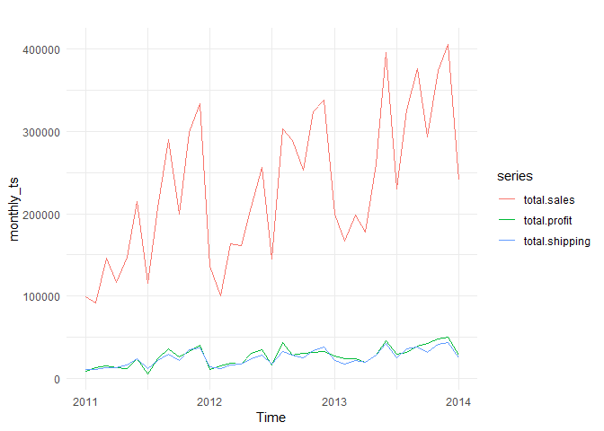

```r
autoplot(monthly_ts) + #without facets
 theme_minimal()
```

Here we see that the sales appears multiplicative in nature, but with the scale being so narrow and small in comparison for profits and shipping, it is harder to tell. Placing this in a facet could help.

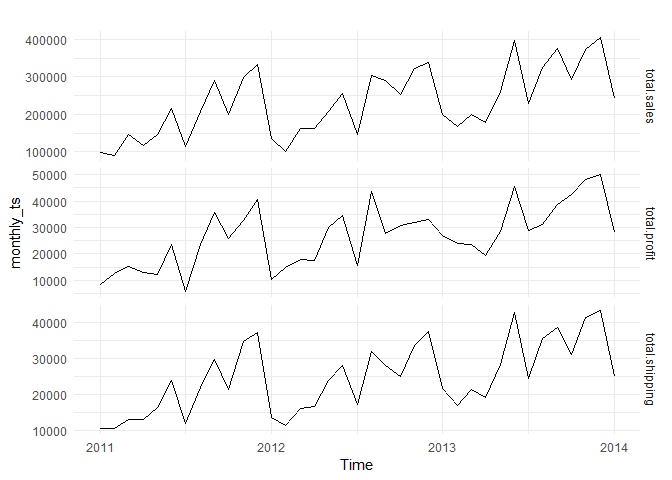

```r
autoplot(monthly_ts, facets = TRUE) + #without facets
 theme_minimal()
```

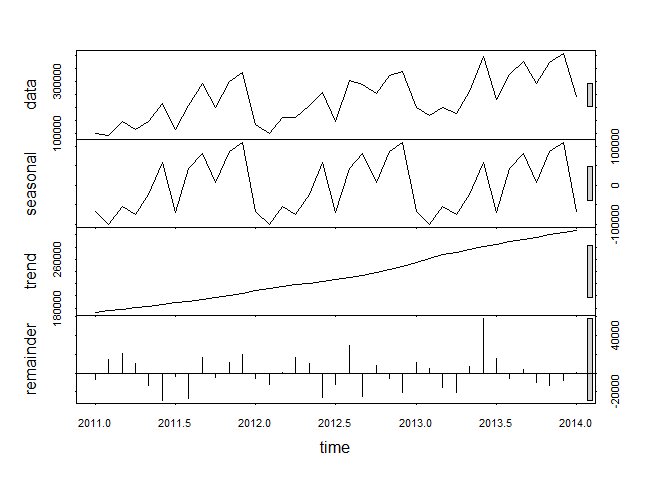

```r
monthly_ts_stl <-stl(sales_ts, s.window = "period")

plot(monthly_ts_stl)
```